# EDA - White Wine (PEDRO BARBOSA DE OLIVEIRA FILHO)

#### Álcool Vs. Qualidade

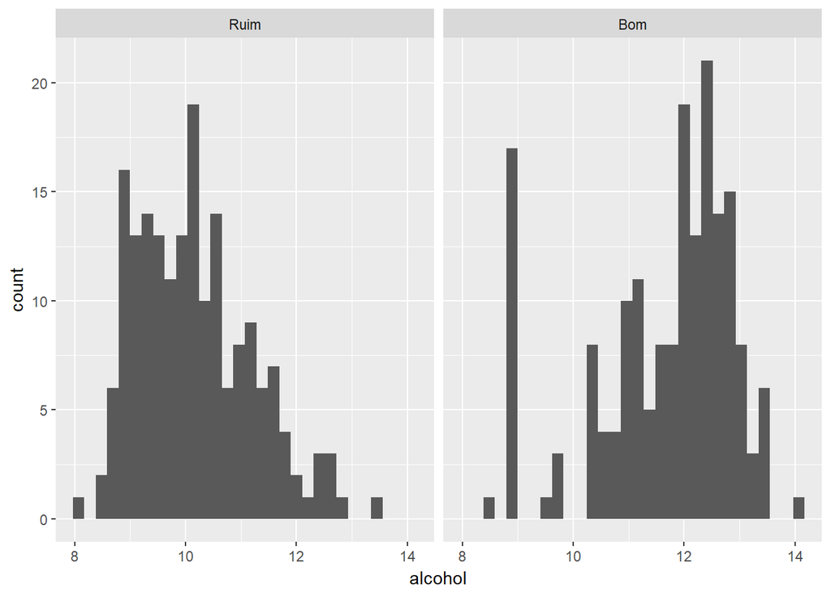

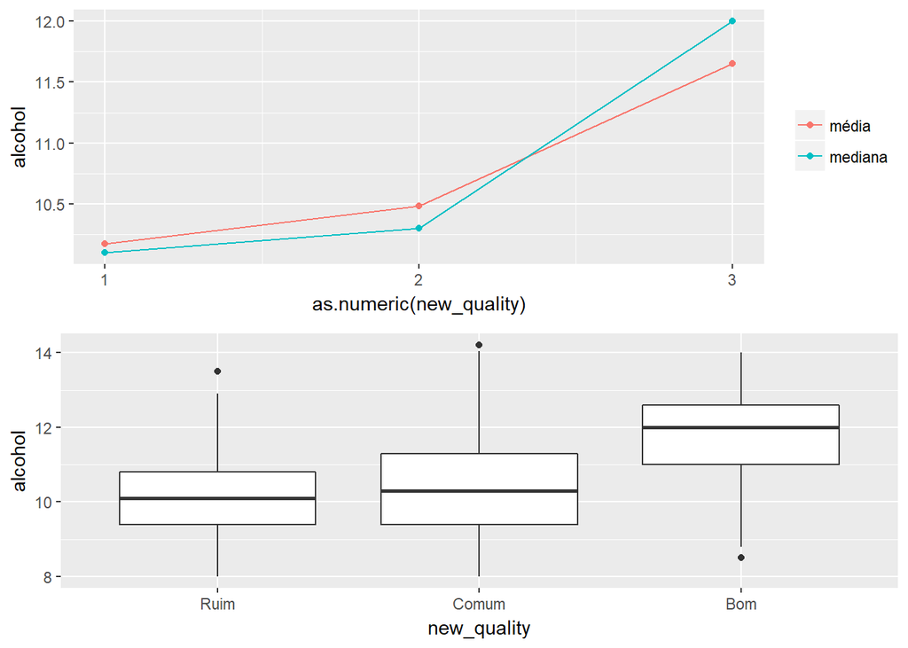

```
## white_wine$new_quality: Ruim
##    Min. 1st Qu.  Median    Mean 3rd Qu.    Max.
##    8.00    9.40   10.10   10.17   10.80   13.50
## --------------------------------------------------------
## white_wine$new_quality: Comum
##    Min. 1st Qu.  Median    Mean 3rd Qu.    Max.
##    8.00    9.40   10.30   10.48   11.30   14.20
## --------------------------------------------------------
## white_wine$new_quality: Bom
##    Min. 1st Qu.  Median    Mean 3rd Qu.    Max.
##    8.50   11.00   12.00   11.65   12.60   14.00
```

Observa-se que vinhos com teor de **álcool** maiores tendem a apesentar melhor qualidade.

# Análise Bivariada

### Discuta sobre alguns dos relacionamentos observados nesta parte da investigação. Como os atributos de interesse variaram no conjunto de dados?

As propriedades químicas mais fortemente correlacionadas com a qualidade dos vinhos brancos estão listadas abaixo:

No decorrer desta análise bivariáda foi dado ênfase aos atributos de interesse listados abaixo. Os mesmos estão acompanhados de seus respectivos coeficientes de correlação linear com a variável **qualidade**.

- Acidez volátil (-0.194723)
- Ácido cítrico (-0.0092091)
- Açúcar residual (-0.0975768)
- Dióxido de enxofre total (-0.1747372)
- Cloretos (-0.2099344)
- Densidade (-0.3071233)
- Porcentagem de álcool (0.4355747)

Algumas observações apresentadas na **Seção de Gráficos Bnivariados** são recaptuladas abaixo:

- Não foi observada diferença significativa entre as concentrações de **acidez volátil** para os vinhos *Comum* e *Bom* (apresentam o mesmo valor mediano).
- Vinhos brancos classificados como *Ruim* apresentaram maior concentração de **acidez volátil**.
- Vinhos brancos classificados como *Ruim* apresentam concentração de **ácido cítrico** levemente inferior a vinhos *Comuns* e *Bons*.
- O comportamento bimodal da concentração de **açúcar residual** é reafirmado.
- Vinhos *Bons* apresentam baixas concentrações de **cloretos**.
- Concentrações de **dióxido de enxofre total** superiores a 50 ppm não aparentam influenciar a qualidade do vinho branco.
- Os melhores vinhos apresentam as menores **densidades**.
- Os melhores vinhos apresentam o maior teor de **álcool**.

### Você observou algum relacionamento interessante entre os outros atributos (os que não são de interesse)?

Foi interessante verificar que as estatísticas medianas das concentrações de **acidez volátil** e **ácido cítrico**, para vinhos brancos classificados como *Comuns* ou *Bons* apresentaram os mesmos valores.

Outro relacionamento interessante, porêm esperadado, foram as fortes correlações lineares entre **densidade** e **açúcar residual** (0.8389665) e **densidade** e **álcool** (-0.7801376).

### Qual foi o relacionamento mais forte encontrado?

A análise bivariada revelou que o relacionamento mais forte envolvendo a variável qulidade está entre a porcentagem de álcool e a qualidade do vinho, que apresentou uma correlação linear moderada positiva de 0.4355747.

# Seção de Gráficos Multivariados

#### Álcool & Densidade Vs. Qualidade

Avaliou-se as duas propriedades químicas que apresentaram a maior correlação com a qualidade do vinho branco. É interessante notar que a porcentagem de álcool e a densidade do vinho branco também apresentam uma forte correlação entre si (-0.7801376).

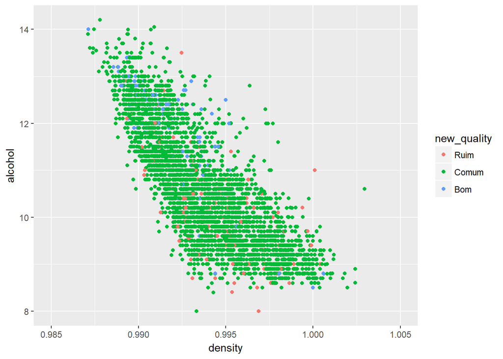

O gráfico acima confirma a forte correlação linear negativa entre as propriedades **densidade** e porcentagem de **álcool**. Entretanto, o mesmo não permite visualizar com clareza a distribuição entre os vinhos *Ruins*, *Comuns* e *Bons*. O gráfico abaixo segrega os pontos por qualidade do vinho branco.

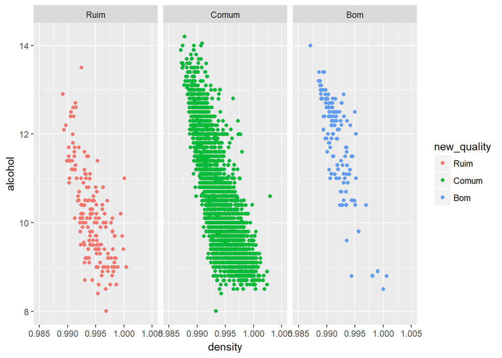

O gráfico acima mostra uma tendência de vinhos brancos com alto teor de álcool e, por consequência, baixa densidade apresentarem a melhor qualidade. Por outro lado, vinhos branco de baixo teor de álcool e alta densidade tendem a apresentar menor qualidade.

Com o objetivo de faciliatr a visualização dos dados, o gráfico abaixo apresenta apenas os vinhos brancos classificados como *Ruins* ou *Bons*.

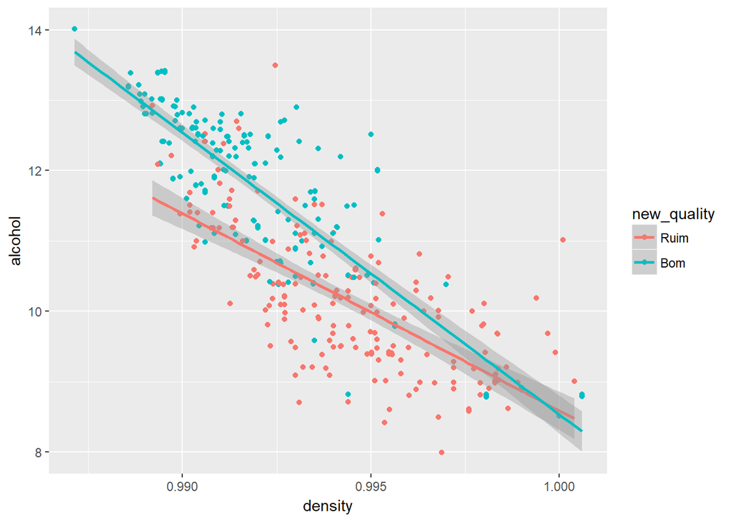

Observando as linhas de tendência é possível perceber para uma mesma densidade, vinhos com maior teor de álcool tendem a apresentar uma melhor qualidade. Esta relação tende a enfraquecer para densidades mais elevadas (ou teores alcólicos mais baixos).

#### Açúcar Residual & Densidade Vs. Qualidade

As propriedades químicas açúcar residual e densidade apresentam a maior correlação entre as propriedades do vinho branco (0.8389665). O gráfico abaixo mostra a variação destas duas propriedades químicas em função da qualidade do vinho branco.

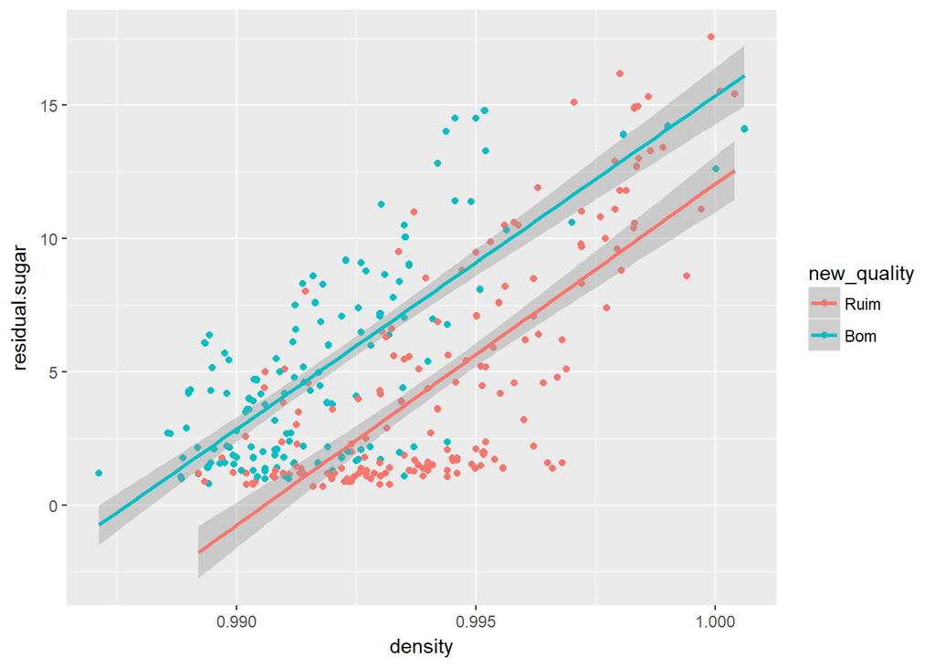

O gráfico acima mostra, que para uma mesma densidade, os vinhos branco com maior concentração de açúcar residual tendem a apresentar melhor qualidade.

#### Açúcar Residual & Álcool Vs. Qualidade

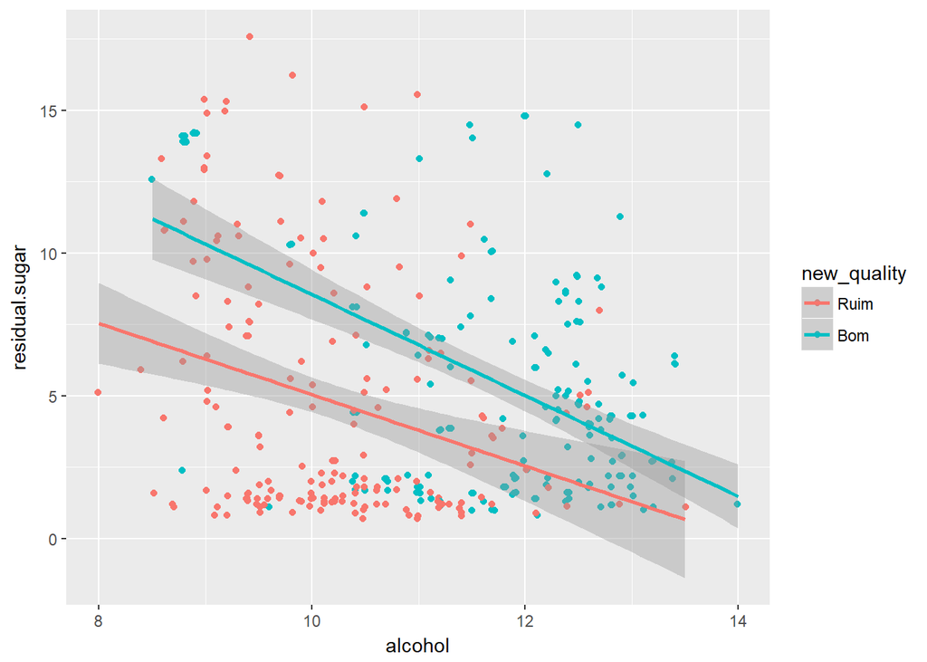

#### Açúcar Residual & Ácido Cítrico Vs. Qualidade

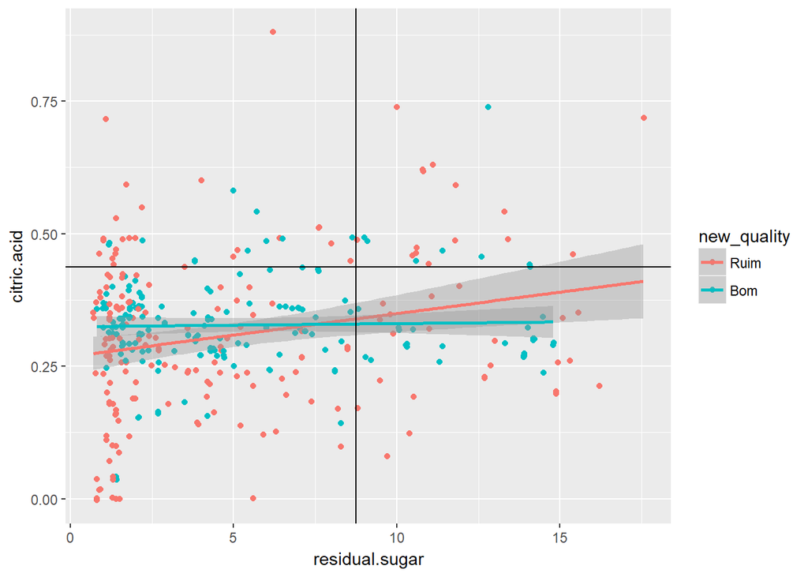

O gráfico acima confirma a quase inexistência de correlação entre as propriedades químicas **ácido cítrico** e **açúcar residual**. Com o auxílio dos quadrantes é possível que vinhos brancos *Ruins* tendem a apresentar baixo **açúcar residual** e baixa concentração de **ácido cítrico**.

#### Álcool & Cloretos Vs. Qualidade

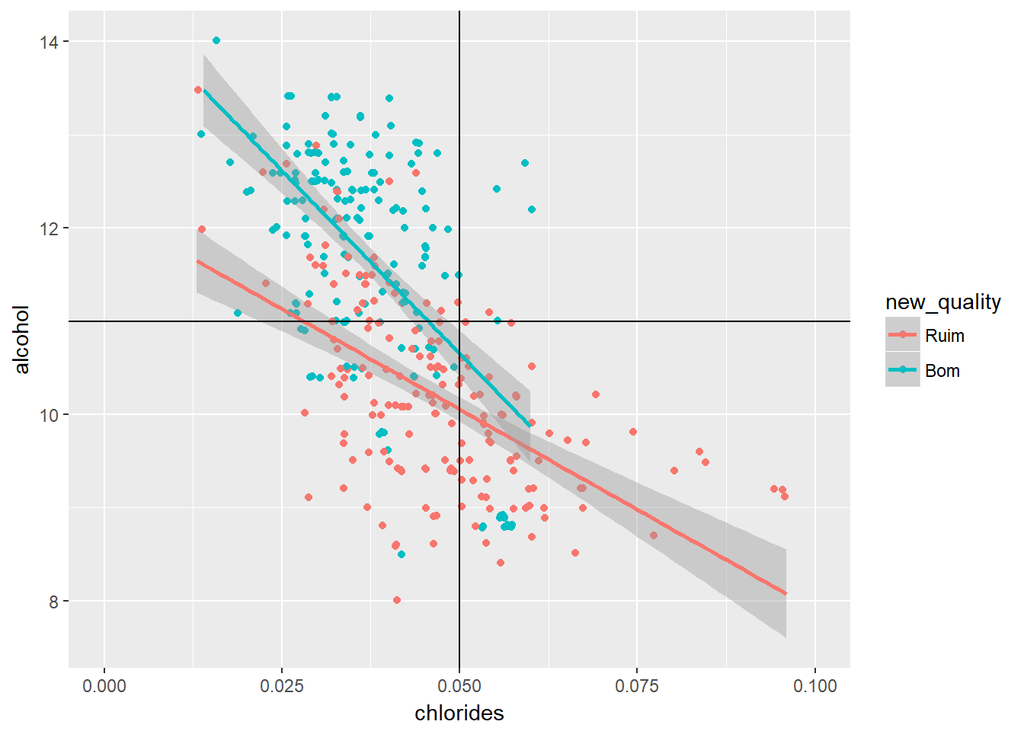

O gráfico acima confirma a correlação linear negativa entra a porcentagem de álcool e concentração de cloretos no vinho branco. Também é possível perceber que os melhores vinhos tendem a apresentar um alto teor de álcool e baixas concentrações de cloretos.

#### Cloretos & Densidade Vs. Qualidade

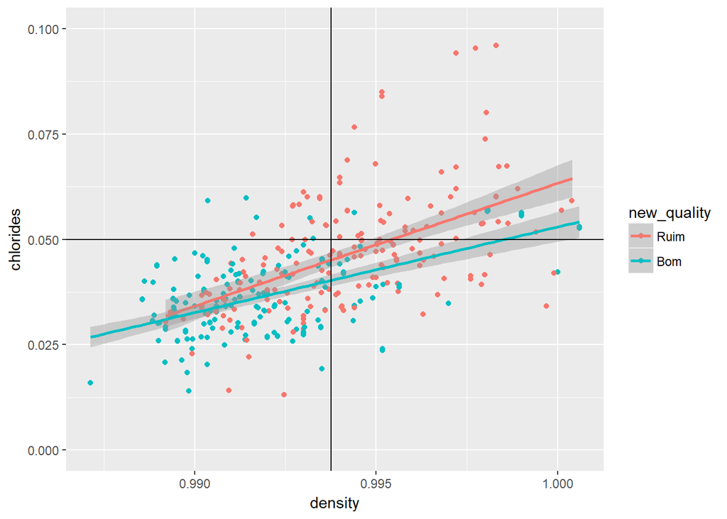

O gráfico acima confirma que bons vinhos apresentam baixa densidade e concentração de cloretos. Para uma mesma densidade, existe pouca diferênça entre as concentrações de cloretos entre vinhos *Bons* e *Ruins*.

# Análise Multivariada

### Discuta sobre os relacionamentos observados nesta parte da investigação. Quais atributos que fortaleceram os demais na observação das variáveis de interesse?

- Para uma mesma densidade, vinhos com maior teor de álcool tendem a apresentar uma melhor qualidade.
- A forte correlação entre as propriedade química densidade e concentração de açúcar residual fortaleceu a hipótese de que a concentração de açúcar residual possa influenciar na qualidade do vinho branco.
- Os melhores vinhos tendem a apresentar um alto teor de álcool e baixas concentrações de cloretos.
- Para uma mesma densidade, existe pouca diferênça entre as concentrações de cloretos entre vinhos *Bons* e *Ruins*.

### Interações surpreendentes e/ou interessantes foram encontradas entre os atributos?

A correlação entre as propriedades químicas densidade, álcool e açucar residual era esperda. Entertanto, foi interessante vericar que, para este conjunto de dados, as propriedades químicas relacionada a acidez e enxofre não apresentaram correlação significativa com a qualidade dos vinhos brancos.

Apesar da distribuição da concentração de açúcar residual apresentar comportamento bimodal e fraca correlação linear com a variável qualidade, foi interessante verificar, que para uma mesma densidade, os vinhos brancos tendem a apresentar uma melhor qualidade para maiores concentrações de açúcar residual.

### OPCIONAL: Modelos foram criados usando este conjunto de dados? Discuta sobre os pontos fortes e as limitações do seu modelo.

Até o presente momento, não criei modelos a partir do banco de dados em estudo.

# Gráficos Finais e Sumário

### Primeiro Gráfico

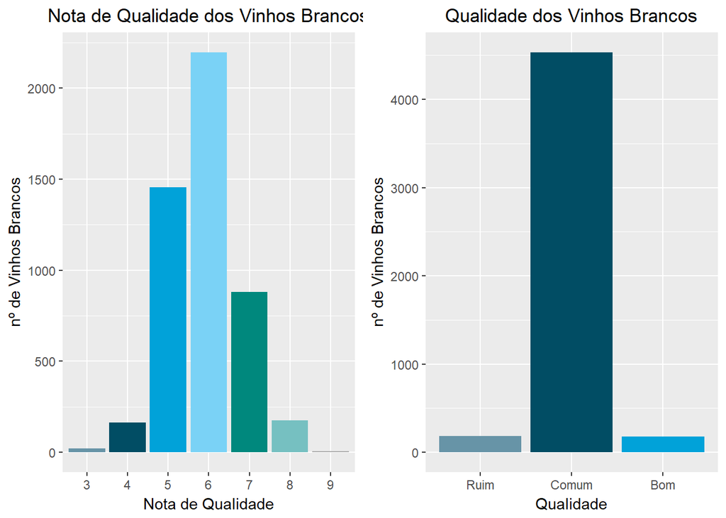

### Descrição do Primeiro Gráfico

O *Primeiro gráfico* apresneta a classificação original da qualidade dos vinhos brancos dada pelos especialistas e a nova classificação de qualidade sugerida pelo autor no decorrer da análise:

- Qualidade 3-4: Ruim
- Qualidade 5-7: Comum
- Qualidade 8-9: Bom

Nota-se que a distribuição das notas de qualidade dos vinhos brancos apresenta comportamento semelhante à distribuição normal, sendo a maioria dos vinhos (> 4000) classificados com notas intermediárias (5, 6 e 7). A nota de qualidade em destaque é a nota 6. Vinhos considerados bons e ruins são igualmente incomuns no conjunto de dados analisado.

### Segundo Gráfico

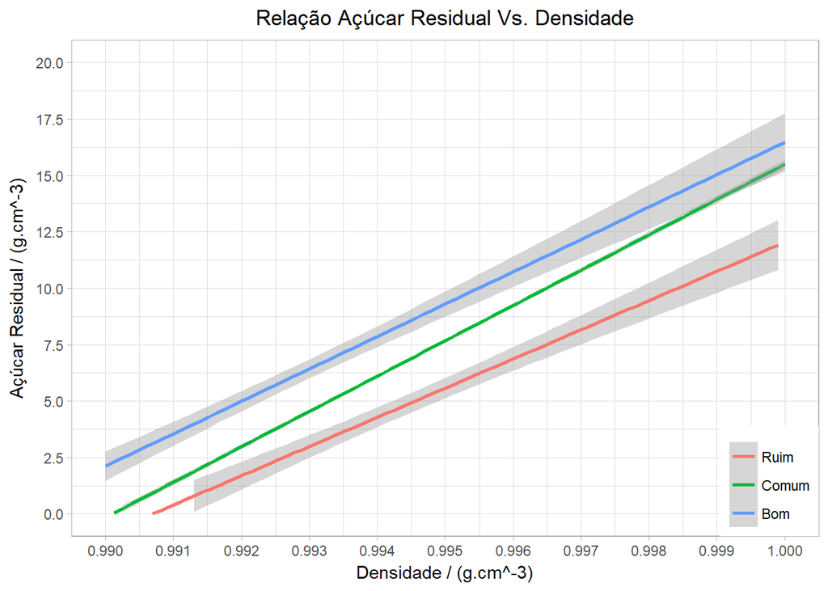

### Descrição do Segundo Gráfico

O *Segundo gráfico* ilustra a forte correlação positiva (0.8389665) entre a concentração de açúcar residual e densidade dos vinhos brancos através de linhas de tendência. O objetivo é mostrar que, apesar da quase inexistência de correlação entre a concentração de açúcar residual e a qualidade dos vinhos brancos (-0.0975768), considerando uma mesma densidade, os melhores vinhos brancos tendem a apresentar maior concentração de açúcar residual.

### Terceiro Gráfico

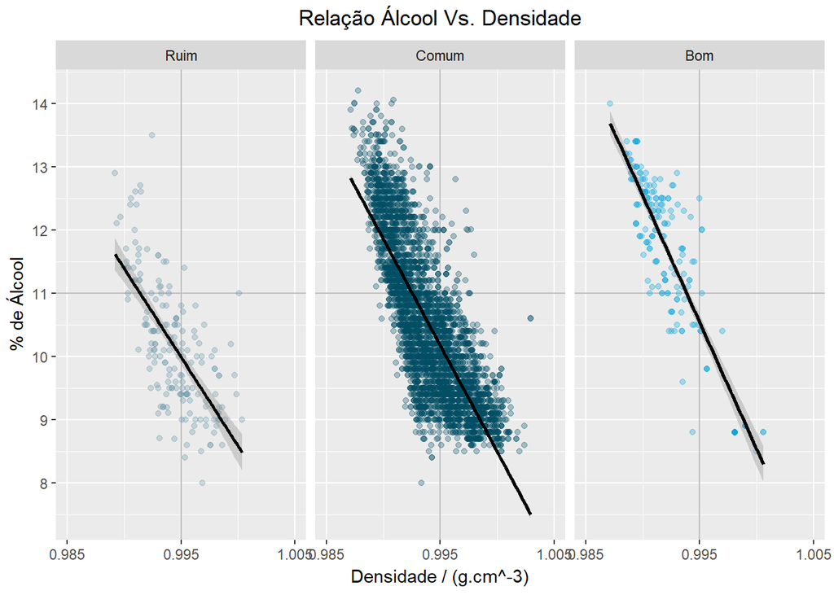

### Descrição do Terceiro Gráfico

O *Terceiro Gráfico* deixa claro a forte correlação linear (-0.7801376) existente entre o teor de álcool e a densidade do vinho branco. A divisão dos planos cartesianos em quadrantes tem o objetivo de facilitar a visualização. Nota-se que os melhores vinhos brancos são aqueles que apresentam o maior teor de álcool e, por consequência, a menor densidade.

# Reflexão

A presente análise exploratória dos dados referentes às propriedades químicas e qualidade de vinhos brancos apontou para as seguintes conclusões:

1. Vinhos com qualidade igual a 6 são mais frequentes.
2. As propriedades químicas **densidade** e **açúcar residual** apresentam a mais forte correlação dentre as variáveis esploradas (0.8389665), indicando que quando a concentração de açúcar residual aumenta, a densidade também aumenta.
3. As propriedades químicas porcentágem de **álcool** e **densidade** apresentam uma forte correlação linear negativa (-0.7801376), indicando que quanto maior a concentração de álcool, menor será a densidade do vinho branco.
4. A propriedade química **cloretos** apresenta a terceira maior correlação linear com a variável **qualidade** (-0.2099344).
5. As variáveis **cloretos** e **álcool** apresnetam uma correlação linear negativa (-0.3601887).
6. As variáveis **cloretos** e **densidade** apresnetam uma correlação linear positiva (0.2572113).

Não é possível desconsiderar o gosto pessoal dos especialistas que avaliaram os vinhos brancos. Seria interessante e enriquecedor para a análise conhecer a nota de cada especialista para cada vinho. O conhecimento de outras variáveis como ano da safra, tipo da uva e marca do vinho também entiqueceriam a análise.

Em análises futuras pretendo criar de modelos de previsão.

# Referências

P. Cortez, A. Cerdeira, F. Almeida, T. Matos and J. Reis. Modeling wine preferences by data mining from physicochemical properties. In Decision Support Systems, Elsevier, 47(4):547-553. ISSN: 0167-9236.

Available at:

- [@Elsevier] http://dx.doi.org/10.1016/j.dss.2009.05.016
- [Pre-press (pdf)] http://www3.dsi.uminho.pt/pcortez/winequality09.pdf
- [bib] http://www3.dsi.uminho.pt/pcortez/dss09.bib